# Imports

```python
import pandas as pd
import seaborn as sns
import numpy as np
import matplotlib.pyplot as plt
from datetime import datetime
from statsmodels.tsa.arima_model import ARIMA
from statsmodels.graphics.tsaplots import plot_acf, plot_pacf
from statsmodels.tsa.seasonal import seasonal_decompose
from statsmodels.api import OLS
import statsmodels.api as sm
import warnings
warnings.filterwarnings("ignore")

plt.style.use('Solarize_Light2')
```

```python
origin_data = pd.read_csv("data.csv")
data = pd.read_csv("data.csv")
data.head()
```

|  | Tarih | Saat | Tuketim_Miktari |
| --- | --- | --- | --- |
| 0 | 01.01.2016 | 0:00 | 26.277,24 |
| 1 | 01.01.2016 | 1:00 | 24.991,82 |
| 2 | 01.01.2016 | 2:00 | 23.532,61 |
| 3 | 01.01.2016 | 3:00 | 22.464,78 |
| 4 | 01.01.2016 | 4:00 | 22.002,91 |

```python
data["Date"] = data["Tarih"] + " " + data["Saat"]
data["Date"] = data["Date"].apply(lambda x: datetime.strptime(x,"%d.%m.%Y %H:%M"))
data["Tuketim_Miktari"] = data["Tuketim_Miktari"].apply(lambda x: x.split(",")[0])
data["Tuketim_Miktari"] = data["Tuketim_Miktari"].apply(lambda x: x.replace(".",""))
data["Tuketim_Miktari"] = data["Tuketim_Miktari"].apply(lambda x: int(x))
data = data.drop(["Saat","Tarih"],axis =1 )
timeseries = data["Tuketim_Miktari"]
```

```python
len(timeseries)
```

```
2784
```

# Explorotary

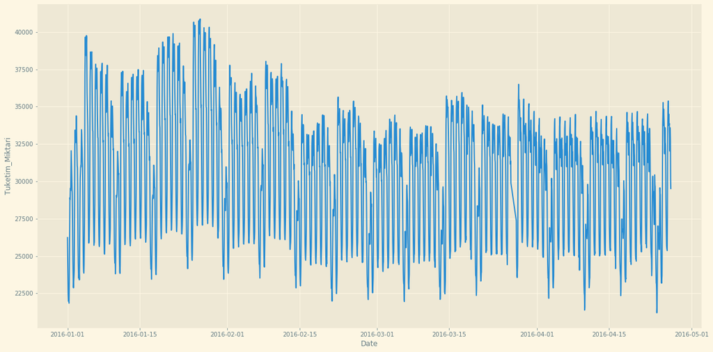

```python
f, ax = plt.subplots(figsize=(20, 10))
sns.lineplot(x="Date",y ="Tuketim_Miktari",data=data)
```

## Rolling window 24

From the rolling analysis we see that if the window is 24(daily) there is still deviation on the rolling mean that indicates that there is still seasonality is hidden in the data. When the window is 168(weekly), the rolling mean is stable and the 168 lag differenced detrend data has small devations; therefore it is good estimator of seasonality. When the rolling window is 720, the rolling mean is also stable however the 720 lag differenced detrend data shows more deviations from 0 than 168 lag differenced detrend data. Therefore choosing 168 for seasonality seems to be the best option.

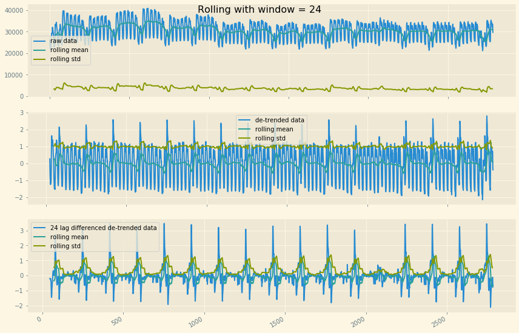

```python
data['z_data'] = (data['Tuketim_Miktari'] - data.Tuketim_Miktari.rolling(window=24).mean()) / data.Tuketim_Miktari.rolling(window=24).std()
data['zp_data'] = data['z_data'] - data['z_data'].shift(24)

fig, ax = plt.subplots(3,figsize=(12, 9))
ax[0].plot(data.index, data.Tuketim_Miktari, label='raw data')
ax[0].plot(data.Tuketim_Miktari.rolling(window=24).mean(), label="rolling mean");
ax[0].plot(data.Tuketim_Miktari.rolling(window=24).std(), label="rolling std ");
ax[0].legend()

ax[1].plot(data.index, data.z_data, label="de-trended data")
ax[1].plot(data.z_data.rolling(window=24).mean(), label="rolling mean");
ax[1].plot(data.z_data.rolling(window=24).std(), label="rolling std ");
ax[1].legend()

ax[2].plot(data.index, data.zp_data, label="24 lag differenced de-trended data")
ax[2].plot(data.zp_data.rolling(window=24).mean(), label="rolling mean");
ax[2].plot(data.zp_data.rolling(window=24).std(), label="rolling std ");
ax[2].legend()


fig.suptitle('Rolling with window = 24', fontsize=16)
plt.tight_layout()
fig.autofmt_xdate()
```

## Rolling window 168

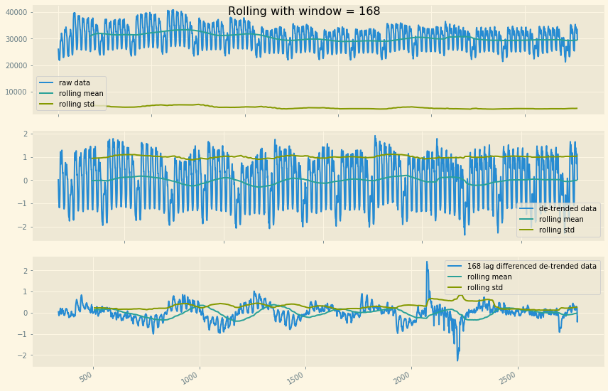

```python
data['z_data'] = (data['Tuketim_Miktari'] - data.Tuketim_Miktari.rolling(window=168).mean()) / data.Tuketim_Miktari.rolling(window=168).std()
data['zp_data'] = data['z_data'] - data['z_data'].shift(168)

fig, ax = plt.subplots(3,figsize=(12, 9))
ax[0].plot(data.index, data.Tuketim_Miktari, label='raw data')
ax[0].plot(data.Tuketim_Miktari.rolling(window=168).mean(), label="rolling mean");
ax[0].plot(data.Tuketim_Miktari.rolling(window=168).std(), label="rolling std");
ax[0].legend()

ax[1].plot(data.index, data.z_data, label="de-trended data")
ax[1].plot(data.z_data.rolling(window=168).mean(), label="rolling mean");
ax[1].plot(data.z_data.rolling(window=168).std(), label="rolling std");
ax[1].legend()

ax[2].plot(data.index, data.zp_data, label="168 lag differenced de-trended data")
ax[2].plot(data.zp_data.rolling(window=168).mean(), label="rolling mean");
ax[2].plot(data.zp_data.rolling(window=168).std(), label="rolling std");
ax[2].legend()


fig.suptitle('Rolling with window = 168', fontsize=16)
plt.tight_layout()
fig.autofmt_xdate()
```

## Rolling window 720

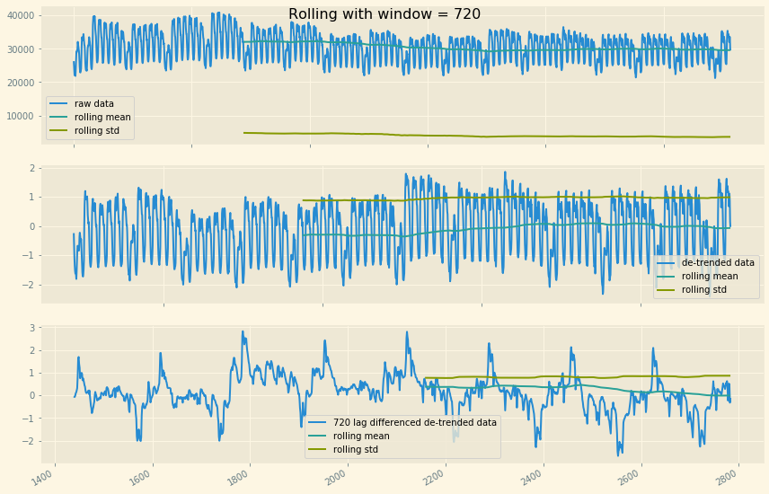

```python
data['z_data'] = (data['Tuketim_Miktari'] - data.Tuketim_Miktari.rolling(window=720).mean()) / data.Tuketim_Miktari.rolling(window=720).std()
data['zp_data'] = data['z_data'] - data['z_data'].shift(720)

fig, ax = plt.subplots(3,figsize=(12, 9))
ax[0].plot(data.index, data.Tuketim_Miktari, label='raw data')
ax[0].plot(data.Tuketim_Miktari.rolling(window=720).mean(), label="rolling mean");
ax[0].plot(data.Tuketim_Miktari.rolling(window=720).std(), label="rolling std");
ax[0].legend()

ax[1].plot(data.index, data.z_data, label="de-trended data")
ax[1].plot(data.z_data.rolling(window=720).mean(), label="rolling mean");
ax[1].plot(data.z_data.rolling(window=720).std(), label="rolling std");
ax[1].legend()

ax[2].plot(data.index, data.zp_data, label="720 lag differenced de-trended data")
ax[2].plot(data.zp_data.rolling(window=720).mean(), label="rolling mean");
ax[2].plot(data.zp_data.rolling(window=720).std(), label="rolling std");
ax[2].legend()


fig.suptitle('Rolling with window = 720', fontsize=16)
plt.tight_layout()
fig.autofmt_xdate()
```

## Plot ACF

When we look at the autocorrelations for weekly and monthly we see that weekly autocorrelations are almost 0.75 for the beginning of each day and the first differencing autocorrelations are always above 0.8. However, for monthly autocorrelations we see that both on original series' and first order differencing's autocorrelations drop below 0.8. This also indicates that weekly seasonality fits better.

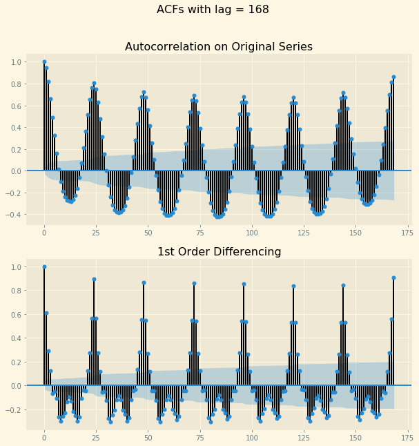

```python
fig = plt.figure(figsize=(10, 10))
ax1 = fig.add_subplot(211)
fig = plot_acf(timeseries, ax=ax1,
               title="Autocorrelation on Original Series",lags = 168)
ax2 = fig.add_subplot(212)
fig = plot_acf(timeseries.diff().dropna(), ax=ax2,
               title="1st Order Differencing",lags = 168)
fig.suptitle('ACFs with lag = 168', fontsize=16)
```

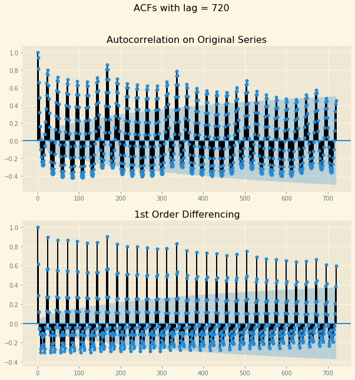

```python
fig = plt.figure(figsize=(10, 10))
ax1 = fig.add_subplot(211)
fig = plot_acf(timeseries, ax=ax1,
               title="Autocorrelation on Original Series",lags = 720)
ax2 = fig.add_subplot(212)
fig = plot_acf(timeseries.diff().dropna(), ax=ax2,
               title="1st Order Differencing",lags = 720)

fig.suptitle('ACFs with lag = 720', fontsize=16)
```

# Decompositions

## Hourly Decomposition

The hourly,daily, weekly and monthly decompositions are given below. The weekly decompositions' residuals follows better normal distribution than any other decomposition as expected since we have already mentioned that weekly seasonality is a good estimator. The monthly decompositions' residuals have more deviation than weekly and it follows a pattern for the whole data. However, weekly decomposition's residuals are more stable and doesn't follow a pattern for whole data. On the other hand, it deviates more at the last four week. That might be due to the consumption at the april doesn't follow the same seasonality as the first three months.

```python
hourly_decom = seasonal_decompose(timeseries, model='additive',period =1)
```

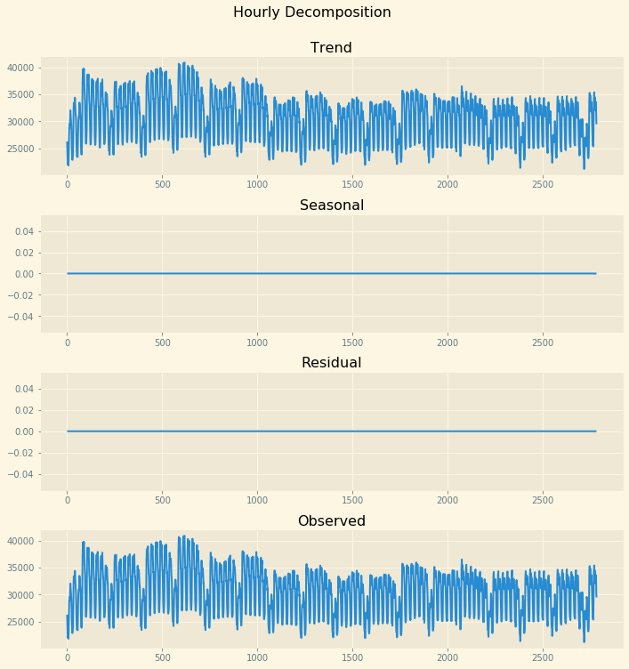

```python
fig = plt.figure(figsize=(10, 10))

fig.suptitle('Hourly Decomposition', fontsize=16,y = 1.04)
ax1 = fig.add_subplot(411)
ax1 = sns.lineplot(data = hourly_decom.trend,ax = ax1)
ax1.set_title("Trend")

ax2 = fig.add_subplot(412)
ax2 = sns.lineplot(data = hourly_decom.seasonal,ax = ax2)
ax2.set_title("Seasonal")

ax3 = fig.add_subplot(413)
ax3 = sns.lineplot(data = hourly_decom.resid,ax = ax3)
ax3.set_title("Residual")

ax4 = fig.add_subplot(414)
ax4 = sns.lineplot(data = hourly_decom.observed,ax = ax4)
ax4.set_title("Observed")

plt.tight_layout()
```

## Daily Decomposition

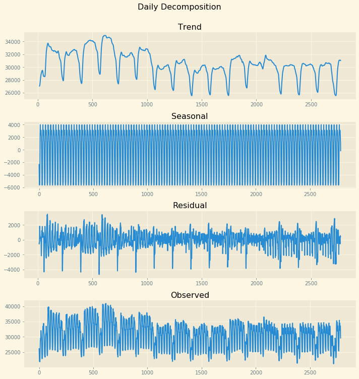

```python
daily_decom = seasonal_decompose(timeseries, model='additive',period =24)
fig = plt.figure(figsize=(10, 10))
fig.suptitle('Daily Decomposition', fontsize=16,y = 1.04)

ax1 = fig.add_subplot(411)
ax1 = sns.lineplot(data = daily_decom.trend,ax = ax1)

ax2 = fig.add_subplot(412)
ax2 = sns.lineplot(data = daily_decom.seasonal,ax = ax2)

ax3 = fig.add_subplot(413)
ax3 = sns.lineplot(data = daily_decom.resid,ax = ax3)

ax4 = fig.add_subplot(414)
ax4 = sns.lineplot(data = daily_decom.observed,ax = ax4)

ax1.set_title("Trend")
ax2.set_title("Seasonal")
ax3.set_title("Residual")
ax4.set_title("Observed")

plt.tight_layout()
```

## Weekly Decomposition

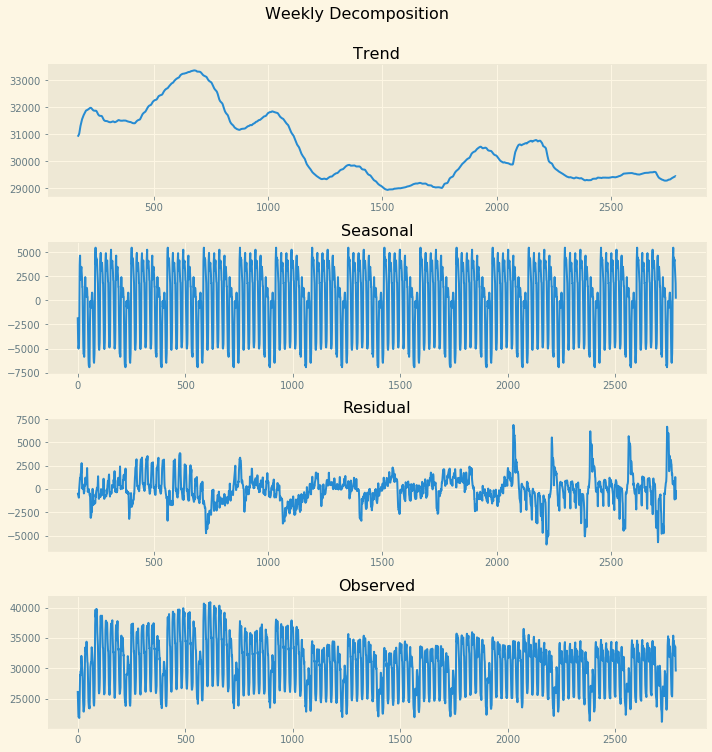

```python
weekly_decom = seasonal_decompose(timeseries, model='additive', period=168,two_sided=False)

fig = plt.figure(figsize=(10, 10))
fig.suptitle('Weekly Decomposition', fontsize=16, y=1.04)

ax1 = fig.add_subplot(411)
ax1 = sns.lineplot(data=weekly_decom.trend, ax=ax1)

ax2 = fig.add_subplot(412)
ax2 = sns.lineplot(data=weekly_decom.seasonal, ax=ax2)

ax3 = fig.add_subplot(413)
ax3 = sns.lineplot(data=weekly_decom.resid, ax=ax3)

ax4 = fig.add_subplot(414)
ax4 = sns.lineplot(data=weekly_decom.observed, ax=ax4)

ax1.set_title("Trend")
ax2.set_title("Seasonal")
ax3.set_title("Residual")
ax4.set_title("Observed")

plt.tight_layout()
```

## Monthly Decomposition

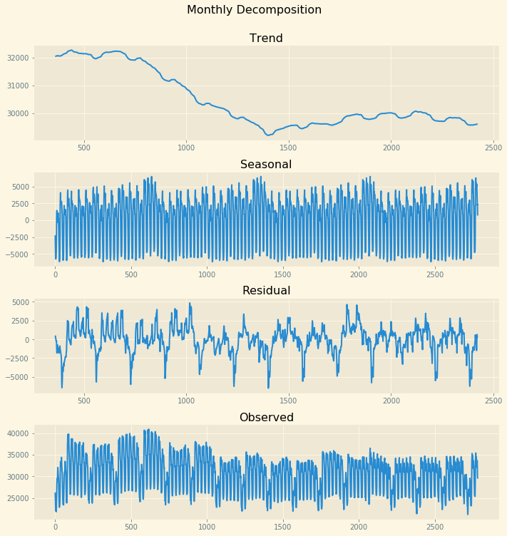

```python
monthly_decom = seasonal_decompose(timeseries, model='additive',period =720)

fig = plt.figure(figsize=(10, 10))
fig.suptitle('Monthly Decomposition', fontsize=16,y = 1.04)

ax1 = fig.add_subplot(411)
ax1 = sns.lineplot(data = monthly_decom.trend,ax = ax1)

ax2 = fig.add_subplot(412)
ax2 = sns.lineplot(data = monthly_decom.seasonal,ax = ax2)

ax3 = fig.add_subplot(413)
ax3 = sns.lineplot(data = monthly_decom.resid,ax = ax3)

ax4 = fig.add_subplot(414)
ax4 = sns.lineplot(data = monthly_decom.observed,ax = ax4)

ax1.set_title("Trend")
ax2.set_title("Seasonal")
ax3.set_title("Residual")
ax4.set_title("Observed")

plt.tight_layout()
```

# Model

```python
x, y = np.arange(len(weekly_decom.trend.dropna())),weekly_decom.trend.dropna()
x = sm.add_constant(x)
model = OLS(y,x)
result_OLS = model.fit()
print(result.summary())
```

```
                            OLS Regression Results
==============================================================================
Dep. Variable:                  trend   R-squared:                       0.549
Model:                            OLS   Adj. R-squared:                  0.548
Method:                 Least Squares   F-statistic:                     3177.
Date:                Thu, 07 May 2020   Prob (F-statistic):               0.00
Time:                        20:24:14   Log-Likelihood:                -21351.
No. Observations:                2616   AIC:                         4.271e+04
Df Residuals:                    2614   BIC:                         4.272e+04
Df Model:                           1
Covariance Type:            nonrobust
==============================================================================
                 coef    std err          t      P>|t|      [0.025      0.975]
------------------------------------------------------------------------------
const       3.212e+04     33.160    968.647      0.000    3.21e+04    3.22e+04
x1            -1.2380      0.022    -56.369      0.000      -1.281      -1.195
==============================================================================
Omnibus:                       83.930   Durbin-Watson:                   0.000
Prob(Omnibus):                  0.000   Jarque-Bera (JB):               40.518
Skew:                           0.061   Prob(JB):                     1.59e-09
Kurtosis:                       2.402   Cond. No.                     3.02e+03
==============================================================================

Warnings:
[1] Standard Errors assume that the covariance matrix of the errors is correctly specified.
[2] The condition number is large, 3.02e+03. This might indicate that there are
strong multicollinearity or other numerical problems.
```

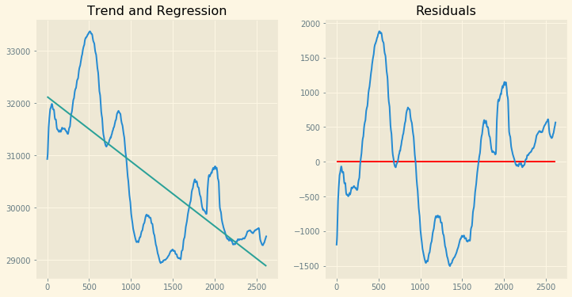

```python
fig, ax = plt.subplots(1, 2, figsize=(12,6));
ax[0].plot(weekly_decom.trend.dropna().values, label='trend')
ax[0].plot(result_OLS.predict())
ax[1].plot(result_OLS.resid.values)
ax[1].hlines(0, 0, len(result_OLS.resid), color='r')
ax[0].set_title("Trend and Regression")
ax[1].set_title("Residuals")
```

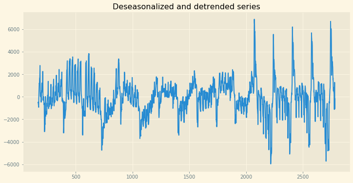

```python
stationary_series = (timeseries - weekly_decom.trend- weekly_decom.seasonal)

fig, ax = plt.subplots(1, 1, figsize=(12,6));
ax.plot(stationary_series.dropna())
ax.set_title("Deseasonalized and detrended series")
```

## AR models

ARMA Model Results

| Dep. Variable: | y | No. Observations: | 2616 |
| --- | --- | --- | --- |
| Model: | ARMA(1, 0) | Log Likelihood | -19948.747 |
| Method: | css-mle | S.D. of innovations | 495.857 |
| Date: | Thu, 07 May 2020 | AIC | 39903.494 |
| Time: | 20:14:50 | BIC | 39921.102 |
| Sample: | 0 | HQIC | 39909.871 |

|  | coef | std err | z | P>\|z\| | [0.025 | 0.975] |
| --- | --- | --- | --- | --- | --- | --- |
| const | -68.4665 | 190.077 | -0.360 | 0.719 | -441.012 | 304.079 |
| ar.L1.y | 0.9494 | 0.006 | 155.615 | 0.000 | 0.937 | 0.961 |

Roots

|  | Real | Imaginary | Modulus | Frequency |
| --- | --- | --- | --- | --- |
| AR.1 | 1.0533 | +0.0000j | 1.0533 | 0.0000 |

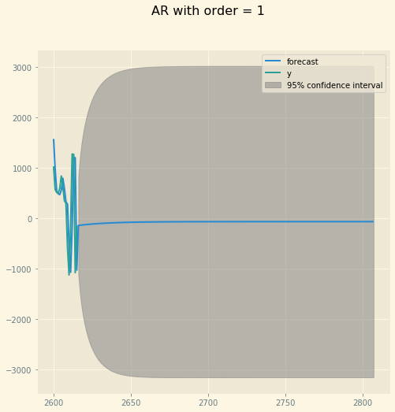

```python
model = ARIMA(stationary_series.dropna(), order = (1,0,0))
results = model.fit()

fig, ax = plt.subplots(1,figsize=(8, 8))
fig.suptitle('AR with order = 1', fontsize=16)
ax =results.plot_predict(2600, 2807, ax = ax)
results.summary()
```

ARMA Model Results

| Dep. Variable: | y | No. Observations: | 2616 |
| --- | --- | --- | --- |
| Model: | ARMA(2, 0) | Log Likelihood | -19740.002 |
| Method: | css-mle | S.D. of innovations | 457.799 |
| Date: | Thu, 07 May 2020 | AIC | 39488.003 |
| Time: | 20:13:57 | BIC | 39511.481 |
| Sample: | 0 | HQIC | 39496.507 |

|  | coef | std err | z | P>\|z\| | [0.025 | 0.975] |
| --- | --- | --- | --- | --- | --- | --- |
| const | -68.4665 | 127.779 | -0.536 | 0.592 | -318.909 | 181.976 |
| ar.L1.y | 1.3143 | 0.018 | 72.803 | 0.000 | 1.279 | 1.350 |
| ar.L2.y | -0.3842 | 0.018 | -21.279 | 0.000 | -0.420 | -0.349 |

Roots

|  | Real | Imaginary | Modulus | Frequency |
| --- | --- | --- | --- | --- |
| AR.1 | 1.1421 | +0.0000j | 1.1421 | 0.0000 |
| AR.2 | 2.2790 | +0.0000j | 2.2790 | 0.0000 |

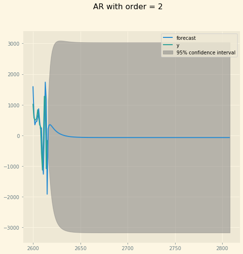

```python
model = ARIMA(stationary_series.dropna(), order = (2,0,0))
results = model.fit()

fig, ax = plt.subplots(1,figsize=(8, 8))
fig.suptitle('AR with order = 2', fontsize=16)
ax =results.plot_predict(2600, 2808, ax = ax)
results.summary()
```

ARMA Model Results

| Dep. Variable: | y | No. Observations: | 2616 |
| --- | --- | --- | --- |
| Model: | ARMA(3, 0) | Log Likelihood | -19681.373 |
| Method: | css-mle | S.D. of innovations | 447.641 |
| Date: | Thu, 07 May 2020 | AIC | 39372.747 |
| Time: | 20:15:28 | BIC | 39402.094 |
| Sample: | 0 | HQIC | 39383.376 |

|  | coef | std err | z | P>\|z\| | [0.025 | 0.975] |
| --- | --- | --- | --- | --- | --- | --- |
| const | -68.4664 | 157.632 | -0.434 | 0.664 | -377.420 | 240.487 |
| ar.L1.y | 1.3961 | 0.019 | 72.839 | 0.000 | 1.359 | 1.434 |
| ar.L2.y | -0.6621 | 0.031 | -21.418 | 0.000 | -0.723 | -0.601 |
| ar.L3.y | 0.2107 | 0.019 | 10.952 | 0.000 | 0.173 | 0.248 |

Roots

|  | Real | Imaginary | Modulus | Frequency |
| --- | --- | --- | --- | --- |
| AR.1 | 1.0786 | -0.0000j | 1.0786 | -0.0000 |
| AR.2 | 1.0315 | -1.8263j | 2.0975 | -0.1682 |
| AR.3 | 1.0315 | +1.8263j | 2.0975 | 0.1682 |

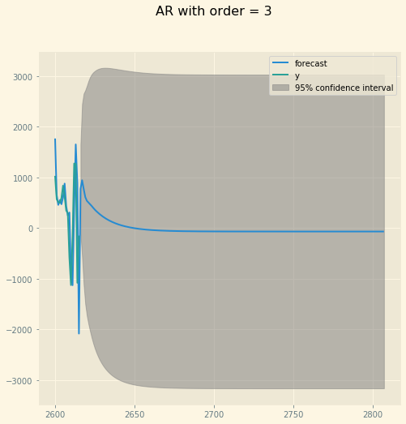

```python
model = ARIMA(stationary_series.dropna(), order = (3,0,0))
results = model.fit()

fig, ax = plt.subplots(1,figsize=(8, 8))
fig.suptitle('AR with order = 3', fontsize=16)
ax =results.plot_predict(2600, 2807, ax = ax)
results.summary()
```

## MA and ARMA models

ARMA Model Results

| Dep. Variable: | y | No. Observations: | 2616 |
| --- | --- | --- | --- |
| Model: | ARMA(0, 1) | Log Likelihood | -21472.706 |
| Method: | css-mle | S.D. of innovations | 887.980 |
| Date: | Thu, 07 May 2020 | AIC | 42951.412 |
| Time: | 20:16:08 | BIC | 42969.020 |
| Sample: | 0 | HQIC | 42957.790 |

|  | coef | std err | z | P>\|z\| | [0.025 | 0.975] |
| --- | --- | --- | --- | --- | --- | --- |
| const | -68.4665 | 33.122 | -2.067 | 0.039 | -133.385 | -3.548 |
| ma.L1.y | 0.9082 | 0.006 | 160.682 | 0.000 | 0.897 | 0.919 |

Roots

|  | Real | Imaginary | Modulus | Frequency |
| --- | --- | --- | --- | --- |
| MA.1 | -1.1011 | +0.0000j | 1.1011 | 0.5000 |

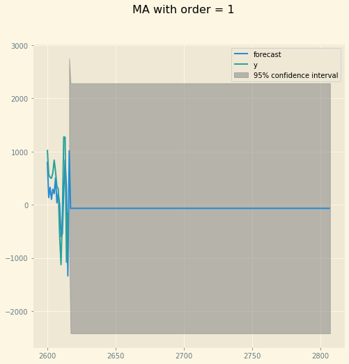

```python
model = ARIMA(stationary_series.dropna(), order = (0,0,1))
results = model.fit()

fig, ax = plt.subplots(1,figsize=(8, 8))
fig.suptitle('MA with order = 1', fontsize=16)
ax =results.plot_predict(2600, 2807, ax = ax)
results.summary()
```

ARMA Model Results

| Dep. Variable: | y | No. Observations: | 2616 |
| --- | --- | --- | --- |
| Model: | ARMA(1, 2) | Log Likelihood | -19678.460 |
| Method: | css-mle | S.D. of innovations | 447.142 |
| Date: | Thu, 07 May 2020 | AIC | 39366.920 |
| Time: | 20:20:23 | BIC | 39396.267 |
| Sample: | 0 | HQIC | 39377.550 |

|  | coef | std err | z | P>\|z\| | [0.025 | 0.975] |
| --- | --- | --- | --- | --- | --- | --- |
| const | -68.4664 | 142.901 | -0.479 | 0.632 | -348.547 | 211.614 |
| ar.L1.y | 0.9074 | 0.009 | 96.545 | 0.000 | 0.889 | 0.926 |
| ma.L1.y | 0.5039 | 0.022 | 22.632 | 0.000 | 0.460 | 0.548 |
| ma.L2.y | 0.0150 | 0.023 | 0.660 | 0.509 | -0.030 | 0.060 |

Roots

|  | Real | Imaginary | Modulus | Frequency |
| --- | --- | --- | --- | --- |
| AR.1 | 1.1020 | +0.0000j | 1.1020 | 0.0000 |
| MA.1 | -2.1179 | +0.0000j | 2.1179 | 0.5000 |
| MA.2 | -31.4868 | +0.0000j | 31.4868 | 0.5000 |

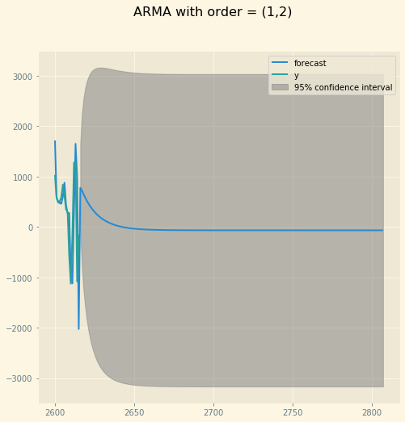

```python
model = ARIMA(stationary_series.dropna(), order = (1,0,2))
results = model.fit()

fig, ax = plt.subplots(1,figsize=(8, 8))
fig.suptitle('ARMA with order = (1,2)', fontsize=16)
ax =results.plot_predict(2600, 2807, ax = ax)
results.summary()
```

ARMA Model Results

| Dep. Variable: | y | No. Observations: | 2616 |
| --- | --- | --- | --- |
| Model: | ARMA(1, 1) | Log Likelihood | -19678.678 |
| Method: | css-mle | S.D. of innovations | 447.179 |
| Date: | Thu, 07 May 2020 | AIC | 39365.356 |
| Time: | 20:20:44 | BIC | 39388.833 |
| Sample: | 0 | HQIC | 39373.859 |

|  | coef | std err | z | P>\|z\| | [0.025 | 0.975] |
| --- | --- | --- | --- | --- | --- | --- |
| const | -68.4664 | 144.827 | -0.473 | 0.636 | -352.323 | 215.390 |
| ar.L1.y | 0.9101 | 0.008 | 109.319 | 0.000 | 0.894 | 0.926 |
| ma.L1.y | 0.4948 | 0.017 | 28.604 | 0.000 | 0.461 | 0.529 |

Roots

|  | Real | Imaginary | Modulus | Frequency |
| --- | --- | --- | --- | --- |
| AR.1 | 1.0988 | +0.0000j | 1.0988 | 0.0000 |
| MA.1 | -2.0208 | +0.0000j | 2.0208 | 0.5000 |

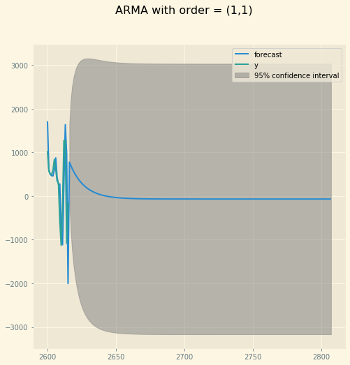

```python
model = ARIMA(stationary_series.dropna(), order=(1, 0, 1))
results_1 = model.fit()

fig, ax = plt.subplots(1, figsize=(8, 8))
fig.suptitle('ARMA with order = (1,1)', fontsize=16)
ax = results_1.plot_predict(2600, 2807, ax=ax)
results_1.summary()
```

ARMA Model Results

| Dep. Variable: | y | No. Observations: | 2616 |
| --- | --- | --- | --- |
| Model: | ARMA(1, 3) | Log Likelihood | -19677.076 |
| Method: | css-mle | S.D. of innovations | 446.905 |
| Date: | Thu, 07 May 2020 | AIC | 39366.152 |
| Time: | 20:17:51 | BIC | 39401.368 |
| Sample: | 0 | HQIC | 39378.908 |

|  | coef | std err | z | P>\|z\| | [0.025 | 0.975] |
| --- | --- | --- | --- | --- | --- | --- |
| const | -68.4664 | 147.888 | -0.463 | 0.643 | -358.322 | 221.389 |
| ar.L1.y | 0.9147 | 0.010 | 92.916 | 0.000 | 0.895 | 0.934 |
| ma.L1.y | 0.4946 | 0.022 | 22.269 | 0.000 | 0.451 | 0.538 |
| ma.L2.y | -0.0103 | 0.026 | -0.389 | 0.697 | -0.062 | 0.042 |
| ma.L3.y | -0.0345 | 0.021 | -1.676 | 0.094 | -0.075 | 0.006 |

Roots

|  | Real | Imaginary | Modulus | Frequency |
| --- | --- | --- | --- | --- |
| AR.1 | 1.0933 | +0.0000j | 1.0933 | 0.0000 |
| MA.1 | -2.3624 | -0.9882j | 2.5607 | -0.4369 |
| MA.2 | -2.3624 | +0.9882j | 2.5607 | 0.4369 |
| MA.3 | 4.4262 | -0.0000j | 4.4262 | -0.0000 |

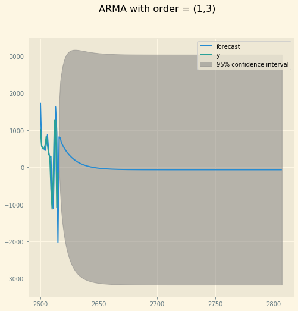

```python
model = ARIMA(stationary_series.dropna(), order=(1, 0, 3))
results = model.fit()

fig, ax = plt.subplots(1, figsize=(8, 8))
fig.suptitle('ARMA with order = (1,3)', fontsize=16)
ax = results.plot_predict(2600, 2807, ax=ax)
results.summary()
```

# Forecast

```python
trend_forecast = [result_OLS.params.x1*i + result_OLS.params.const for i in (np.arange(2784,2808))]
total_forecast = results_1.forecast(24)[0] +  trend_forecast + weekly_decom.seasonal[24*2:24*3]
date = np.array('2016-04-27 00', dtype=np.datetime64)
new_index = date + np.arange(24)
total_forecast = pd.Series(total_forecast.values,index=new_index)
total_lower_ci = (results_1.forecast(24)[2])[:,1] + trend_forecast + weekly_decom.seasonal[24*2:24*3]
total_upper_ci = (results_1.forecast(24)[2])[:,0] + trend_forecast + weekly_decom.seasonal[24*2:24*3]
total_lower_ci = pd.Series(total_lower_ci.values,index=new_index)
total_upper_ci = pd.Series(total_upper_ci.values,index=new_index)
```

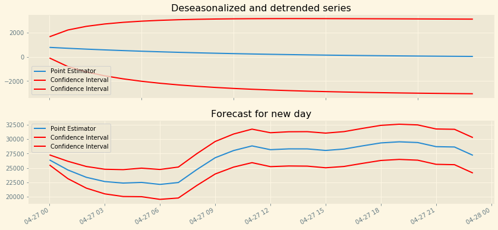

```python
fig, ax = plt.subplots(2,1, figsize=(12,6));
ax[0].plot(results_1.forecast(24)[0],label = "Point Estimator")
ax[0].plot(results_1.forecast(24)[2],label  = "Confidence Interval",c ="r")
ax[0].set_title("Deseasonalized and detrended series")
ax[0].legend()

ax[1].plot(total_forecast,label = "Point Estimator")
ax[1].plot(total_lower_ci,c ="r",label  = "Confidence Interval")
ax[1].plot(total_upper_ci,c ="r",label  = "Confidence Interval")
ax[1].set_title("Forecast for new day")
ax[1].legend()

plt.tight_layout()
fig.autofmt_xdate()
```

```python
total_forecast
```

```
2016-04-27 00:00:00    26393.550505
2016-04-27 01:00:00    24643.896195
2016-04-27 02:00:00    23369.832481
2016-04-27 03:00:00    22633.077503
2016-04-27 04:00:00    22368.997012
2016-04-27 05:00:00    22483.555324
2016-04-27 06:00:00    22135.824205
2016-04-27 07:00:00    22465.428909
2016-04-27 08:00:00    24711.647863
2016-04-27 09:00:00    26771.359789
2016-04-27 10:00:00    28020.913559
2016-04-27 11:00:00    28830.124820
2016-04-27 12:00:00    28172.401593
2016-04-27 13:00:00    28313.752911
2016-04-27 14:00:00    28309.254704
2016-04-27 15:00:00    28039.698348
2016-04-27 16:00:00    28284.754080
2016-04-27 17:00:00    28832.566504
2016-04-27 18:00:00    29348.614174
2016-04-27 19:00:00    29539.048302
2016-04-27 20:00:00    29414.338498
2016-04-27 21:00:00    28700.595706
2016-04-27 22:00:00    28639.330876
2016-04-27 23:00:00    27195.465026
dtype: float64
```